# Niðurstöður — Gróðurbreytingar á náttúruverndarsvæðum Íslands

# 4 Jarðvegsbleyta — kort yfir endurnýjun tegunda og tegundatap

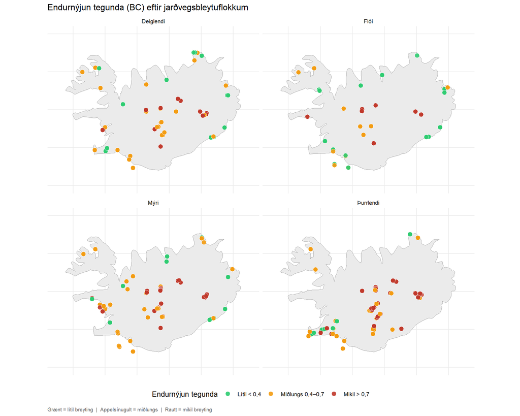

Mynd 4. Endurnýjun tegunda (BC, efri kort) og breyting á tegundafjölda (ΔS, neðri kort) eftir jarðvegsbleytuflokkum. Rautt = mikil breyting / tap; grænt/blátt = stöðugleiki / aukning.

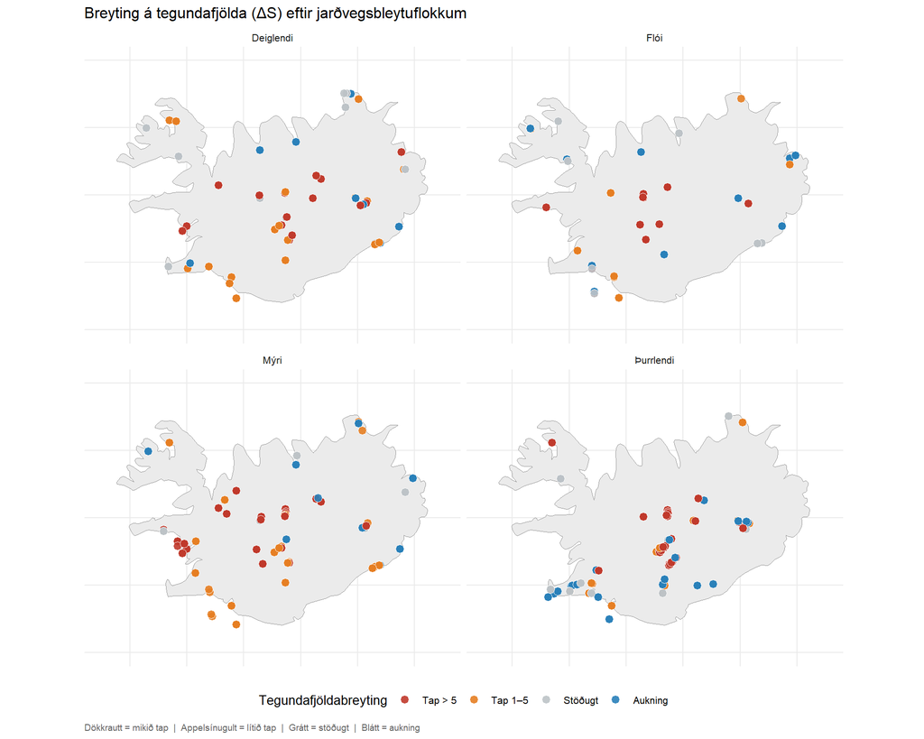

Mynd 4. Endurnýjun tegunda (BC, efri kort) og breyting á tegundafjölda (ΔS, neðri kort) eftir jarðvegsbleytuflokkum. Rautt = mikil breyting / tap; grænt/blátt = stöðugleiki / aukning.

Tafla 2. Endurnýjun tegunda og tegundatap eftir jarðvegsbleytuflokkum. Kruskal–Wallis: BC χ²=13.12 p=0.0044; ΔS χ²=11.06 p=0.0114.

| Jarðvegsbleyta | n reitir | Miðgildi BC | Miðgildi ΔS |
| --- | --- | --- | --- |
| Þurrlendi | 111 | 0.678 | -2 |
| Mýri | 77 | 0.609 | -4 |
| Deiglendi | 70 | 0.526 | -1 |
| Flói | 45 | 0.441 | -1 |

Þurrlendi sýndi hæstu endurnýjun tegunda (BC miðgildi = 0.678) en fremur lítið tegundatap (ΔS miðgildi = -2), sem bendir til þess að tegundasamsetningin sé að breytast — sumar tegundir hverfa en aðrar koma í staðinn — án þess að heildarfjöldi tegunda minnki verulega. Mýrar sýndu hins vegar mest tegundatap (ΔS = -4) án þess að Bray–Curtis-fjarlægðin væri samsvarandi há, sem bendir til þess að tegundir séu að hverfa án þess að nýjar taki við. Þetta eru, í grundvallaratriðum, tveir ólíkir breytingarferlar sem skipta máli fyrir túlkun niðurstaðnanna. —